# Marty Instructor Support Group Data

### **September 25, 2019 to October 09, 2019**

### Session 3

#### **At the end of today’s session, I CAN: Identify the stage of my business and the implications for my business’ focus and goals.**

#### **At the end of today’s session, I CAN: Describe the relationship between different leadership styles and the ability to grow a business.**

#### **At the end of today’s session, I CAN: Reflect to gain a better understanding of my leadership style and its implications for the growth of my business.**

#### **I completed my session prep (e.g. readings, worksheets).**

#### **The instructor effectively managed today’s session agenda (e.g., good time management, covered whole agenda, good facilitation).**

### Session 4

#### **At the end of today’s session, I CAN: Explain the importance of properly capturing and analyzing financial data.**

#### **At the end of today’s session, I CAN: Explain what drives profit in my business.**

#### **At the end of today’s session, I CAN: Describe how financial reports, such as balance sheets, income statements, and cash flow statements, indicate the financial health of my business.**

#### **I completed my session prep (e.g. readings, worksheets).**

#### **The instructor effectively managed today’s session agenda (e.g., good time management, covered whole agenda, good facilitation).**

### Session 5

#### **At the end of today’s session, I CAN: Use NAICS code to compare financial figures from my business to industry standards using a balance sheet and income statement.**

#### **At the end of today’s session, I CAN: Interpret the information on a balance sheet, income statement and cash flow statement in order to identify and create the ratios needed for my Financial Metrics.**

#### **At the end of today’s session, I CAN: Define breakeven point and calculate the breakeven point for my business.**

#### **I completed my session prep (e.g. readings, worksheets).**

#### **The instructor effectively managed today’s session agenda (e.g., good time management, covered whole agenda, good facilitation).**

### Session 6

#### **At the end of today’s session, I CAN: Identify and understand the financial indicators that a bank or other lender will use to look at my business and assess its health.**

#### **At the end of today’s session, I CAN: Create a three month cash flow forecast to demonstrate my ability to develop a twelve month forecast post class.**

#### **At the end of today’s session, I CAN: Understand what drivers affect cash flow and how to utilize them to manage my cash flow.**

#### **I completed my session prep (e.g. readings, worksheets).**

#### **The instructor effectively managed today’s session agenda (e.g., good time management, covered whole agenda, good facilitation).**

### Session 7

#### **At the end of today’s session, I CAN: Recall the definition of marketing and practices applying the S.A.V.E. framework to my business’ products and or services.**

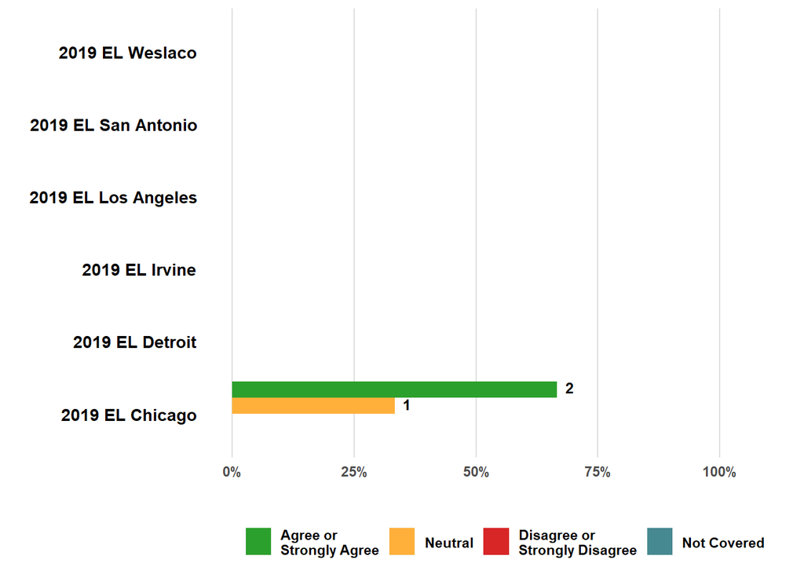

#### **At the end of today’s session, I CAN: Understand the value of my product/service in comparison to my competitors.**

#### **At the end of today’s session, I CAN: Understand my current customers’ perception of my product/service.**

#### **I completed my session prep (e.g. readings, worksheets).**

#### **The instructor effectively managed today’s session agenda (e.g., good time management, covered whole agenda, good facilitation).**

### Session 8

#### **At the end of today’s session, I CAN: Identify my target market(s) and develop a market segmentation strategy.**

#### **At the end of today’s session, I CAN: Identify my ideal customer(s) and develop an ideal customer profile.**

#### **At the end of today’s session, I CAN: Assess the costs and benefits associated with retaining existing customers versus acquiring new customers.**

#### **I completed my session prep (e.g. readings, worksheets).**

#### **The instructor effectively managed today’s session agenda (e.g., good time management, covered whole agenda, good facilitation).**

### Session 9

#### **At the end of today’s session, I CAN: Identify social media tools that could move prospects through the sales pipeline.**

#### **At the end of today’s session, I CAN: Understand the stages of the sales cycle and develop strategies for growing my sales pipeline by increasing my win rate and by decreasing the length of my sales cycle.**

#### **At the end of today’s session, I CAN: Identify blockages in my sales pipeline and develop specific strategies for addressing them.**

#### **I completed my session prep (e.g. readings, worksheets).**

#### **The instructor effectively managed today’s session agenda (e.g., good time management, covered whole agenda, good facilitation).**

### Session 10

#### **At the end of today’s session, I CAN: Identify the employees and managers needed to grow my business over the next 3 years.**

#### **At the end of today’s session, I CAN: Assess my leadership strengths and readiness to hire additional talent.**

#### **At the end of today’s session, I CAN: Identify motivational factors that contribute to a high performance culture.**

#### **I completed my session prep (e.g. readings, worksheets).**

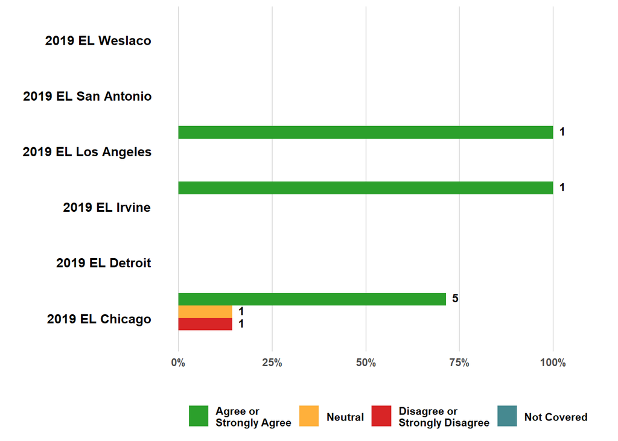

#### **The instructor effectively managed today’s session agenda (e.g., good time management, covered whole agenda, good facilitation).**

### Session 11

#### **At the end of today’s session, I CAN: Explain when to best utilize different types of capital, such as lines of credit, debt equity, and working capital.**

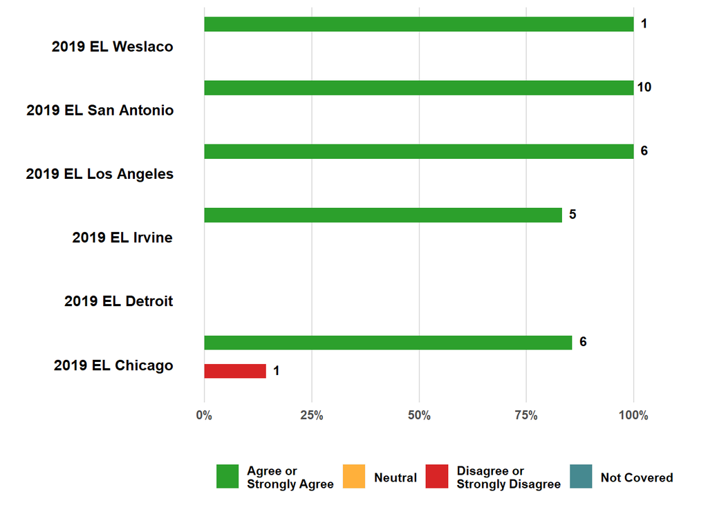

#### **At the end of today’s session, I CAN: Determine what type of funding is appropriate for my business now.**

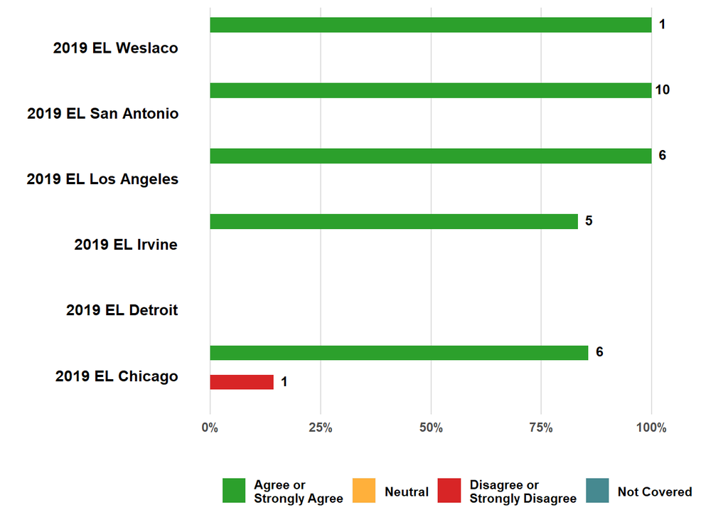

#### **At the end of today’s session, I CAN: Describe the continuum of public funding available from city, state, and federal governments and from private sources (e.g., micro-financing, commercial loans, angel/venture capital).**

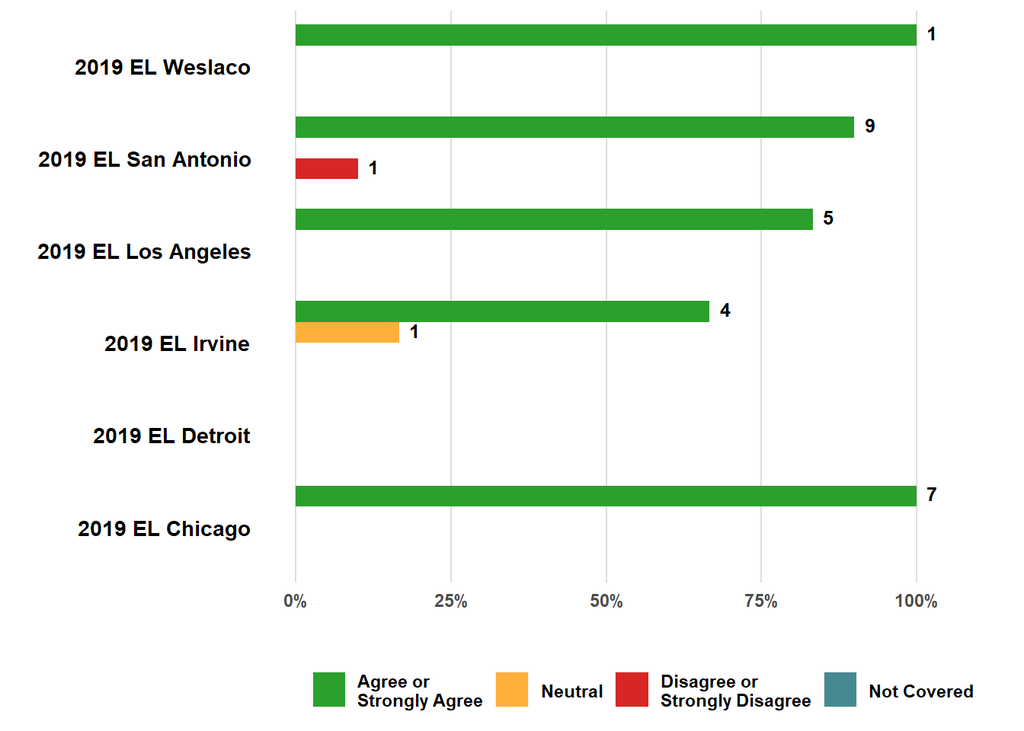

#### **I completed my session prep (e.g. readings, worksheets).**

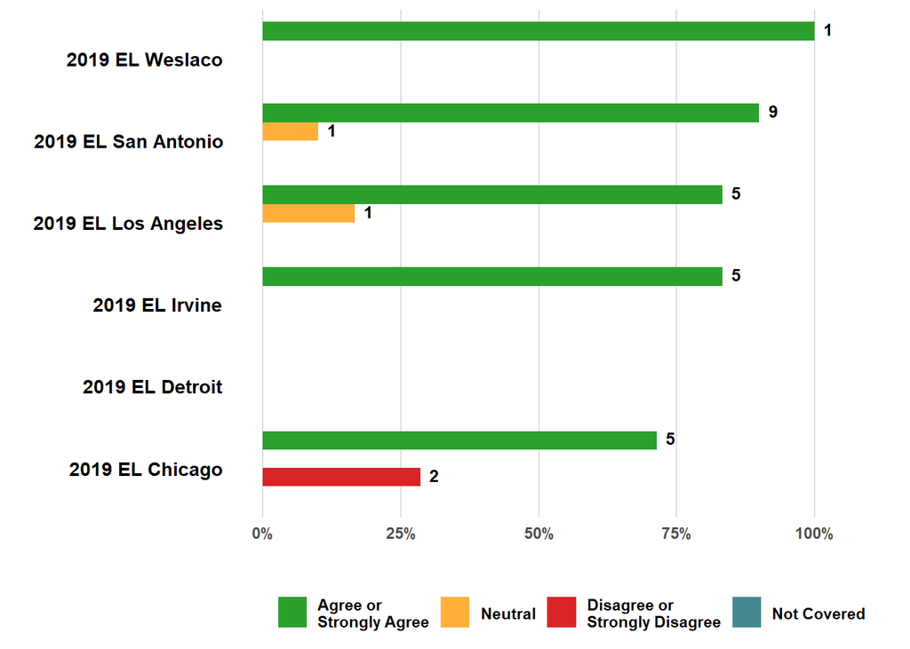

#### **The instructor effectively managed today’s session agenda (e.g., good time management, covered whole agenda, good facilitation).**

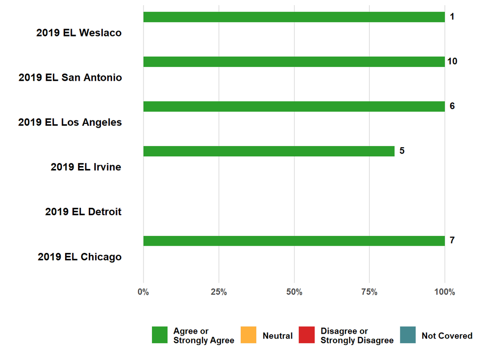

### Session 12

#### **At the end of today’s session, I CAN: Determine what types of contracting are appropriate for my business now.**

#### **At the end of today’s session, I CAN: Ascertain my readiness to secure contracts successfully and what resources exist to help me be successful.**

#### **At the end of today’s session, I CAN: Understand the steps and costs associated with successfully securing contracts with anchor institutions and with local, state, and federal government.**

#### **I completed my session prep (e.g. readings, worksheets).**

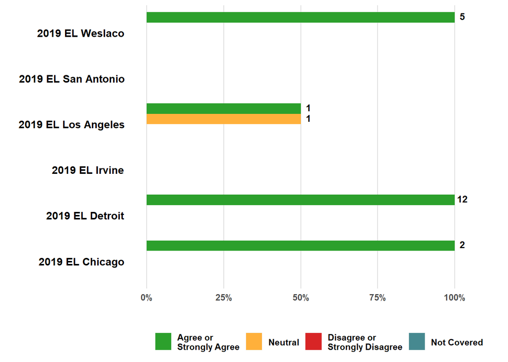

#### **The instructor effectively managed today’s session agenda (e.g., good time management, covered whole agenda, good facilitation).**

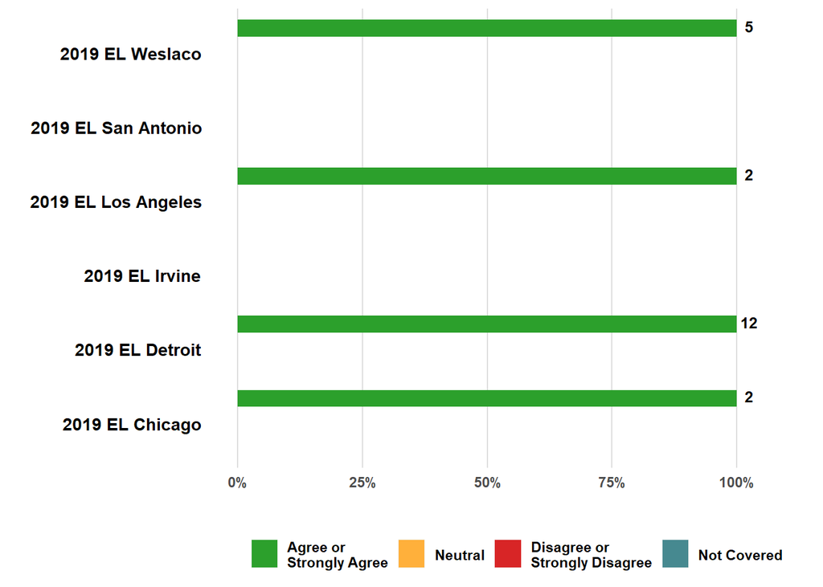